# Final Project

Vinay Warrier

# Final Project

**Render your final RMarkdown with answers in HTML format.**

**Project Objective:** This final project aims to analyze a dataset to gain insights, make data-driven decisions, and present your findings clearly and informally. Through this project, you will demonstrate your understanding of key data science principles and tools. CHOOSE DIFFERENT DATA

**Project Steps:**

1. **Choose a Dataset:** Select a dataset that is interesting to you and has potential for analysis. It could be related to any field, such as economics, social sciences, health, sports, or technology. Make sure the dataset is suitable for your skill level and project timeline.
2. **Data Acquisition:** Obtain the dataset from a reliable source. It could be sourced from public repositories, APIs, or provided by me. Ensure the data is in a format you can work with, such as CSV, Excel, or JSON.
3. **Data Cleaning:** Clean the dataset to handle missing values, outliers, and inconsistencies. This step is crucial as the quality of your analysis depends on the quality of your data. Document the cleaning steps you take.
4. **Exploratory Data Analysis (EDA):** Conduct exploratory analysis to understand the basic characteristics of the data. Calculate summary statistics, create visualizations (histograms, scatter plots, etc.), and identify patterns or trends.
5. **Formulate Hypotheses:** Based on your initial exploration, formulate relevant hypotheses that you aim to test. These hypotheses could relate to relationships between variables, trends over time, group comparisons, or any other aspects you find interesting in the data.
6. **Statistical Analysis:** Choose appropriate statistical techniques to analyze the data and test your hypotheses. This could involve t-tests, correlation analysis, chi-square tests, or other relevant methods.
7. **Statistical Inference:** Apply statistical inference techniques to draw conclusions from your analysis. Use p-values, confidence intervals, and effect sizes to determine the significance and practical implications of your findings.
8. **Interpretation and Conclusion:** Summarize your findings concisely and coherently. What insights did you gain from the data? How do your results address the initial objectives? Were there any unexpected discoveries?
9. **Project Report/Presentation:** Prepare a report or presentation that covers all the project steps. Include visuals, code snippets, and explanations to guide the reader through your process. Use precise language and avoid jargon.

**Project Grading:** Your project will be graded based on the following:

- Data acquisition and preprocessing
- Quality of exploratory analysis
- Clarity and accuracy of visualizations
- Soundness of conclusions drawn
- Overall presentation and documentation

Remember, data science is a blend of technical skills and domain knowledge coupled with the ability to communicate your findings effectively. This project aims to develop your skills in all these areas and provide you with a taste of what real-world data science involves.

Good luck, and please get in touch with me at hajoseph@scarletmail.rutgers.edu if you have any questions!

```r
library(ggplot2)

netflix_data <- read.csv("C:\\Users\\vinay\\OneDrive\\Desktop\\Study Material\\5th Sem\\Intro to Data Science\\Assignments\\Final Project\\Netflix.csv")

summary(netflix_data)
```

```
##      index           id               title               type
##  Min.   :   0   Length:5283        Length:5283        Length:5283
##  1st Qu.:1320   Class :character   Class :character   Class :character
##  Median :2641   Mode  :character   Mode  :character   Mode  :character
##  Mean   :2641
##  3rd Qu.:3962
##  Max.   :5282
##
##   release_year  age_certification     runtime        imdb_id
##  Min.   :1953   Length:5283        Min.   :  0.0   Length:5283
##  1st Qu.:2015   Class :character   1st Qu.: 45.0   Class :character
##  Median :2018   Mode  :character   Median : 87.0   Mode  :character
##  Mean   :2016                      Mean   : 79.2
##  3rd Qu.:2020                      3rd Qu.:106.0
##  Max.   :2022                      Max.   :235.0
##
##    imdb_score      imdb_votes
##  Min.   :1.500   Min.   :      5
##  1st Qu.:5.800   1st Qu.:    521
##  Median :6.600   Median :   2279
##  Mean   :6.533   Mean   :  23407
##  3rd Qu.:7.400   3rd Qu.:  10144
##  Max.   :9.600   Max.   :2268288
##                  NA's   :16
```

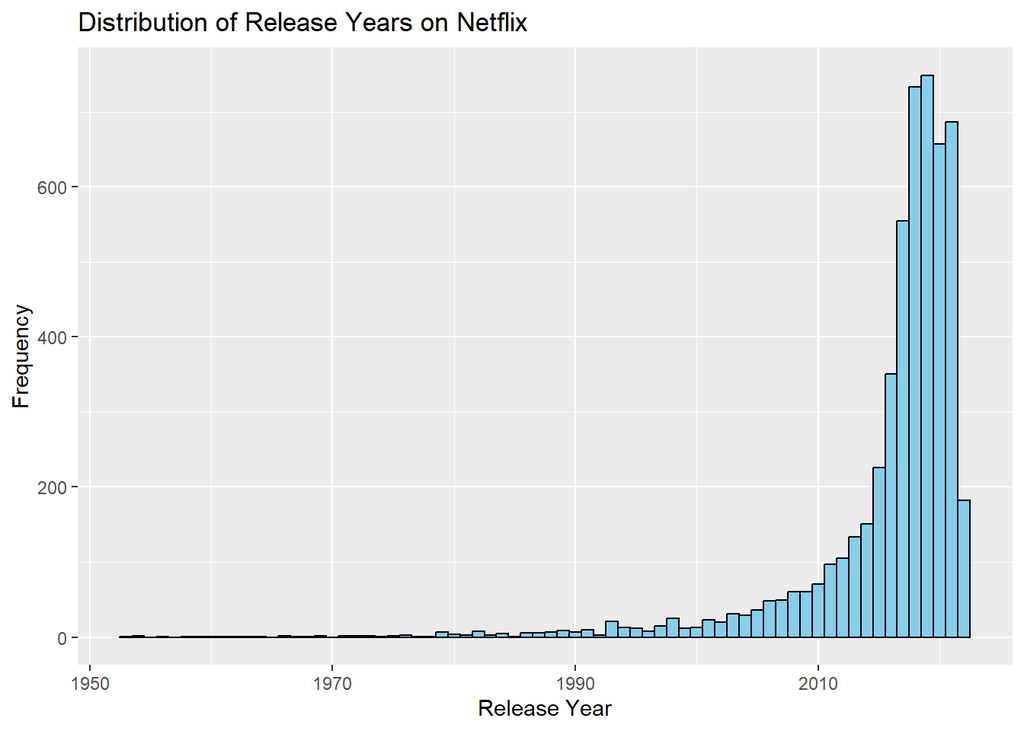

```r
ggplot(netflix_data, aes(x = release_year)) +
  geom_histogram(binwidth = 1, fill = "skyblue", color = "black") +
  labs(title = "Distribution of Release Years on Netflix",
       x = "Release Year", y = "Frequency")
```

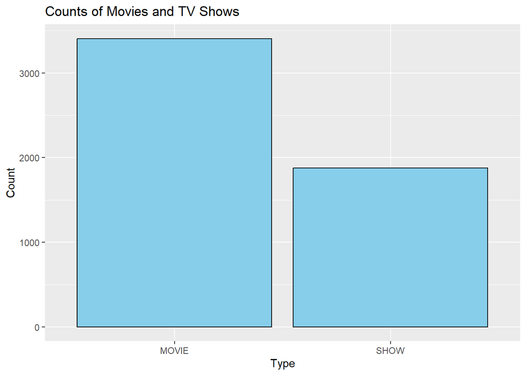

```r
ggplot(netflix_data, aes(x = type)) +
  geom_bar(fill = "skyblue", color = "black") +
  labs(title = "Counts of Movies and TV Shows",
       x = "Type", y = "Count")
```

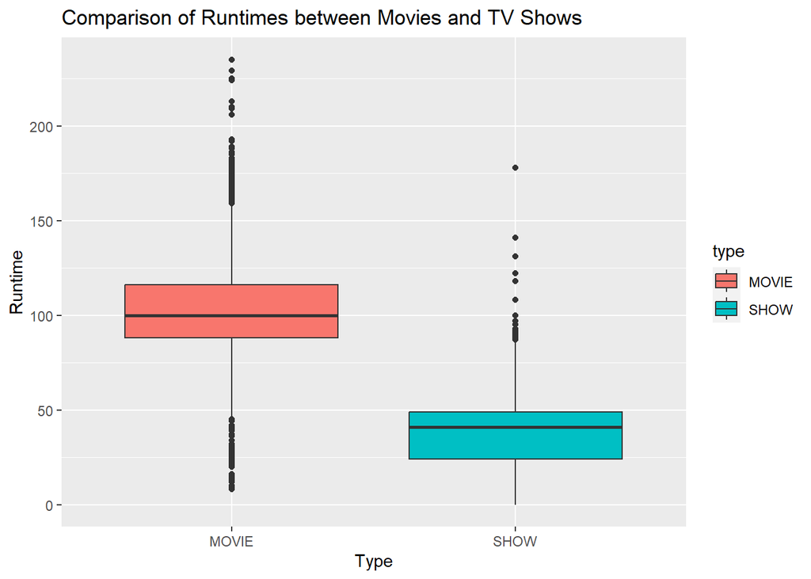

```r
ggplot(netflix_data, aes(x = type, y = runtime, fill = type)) +
  geom_boxplot() +
  labs(title = "Comparison of Runtimes between Movies and TV Shows",
       x = "Type", y = "Runtime")
```

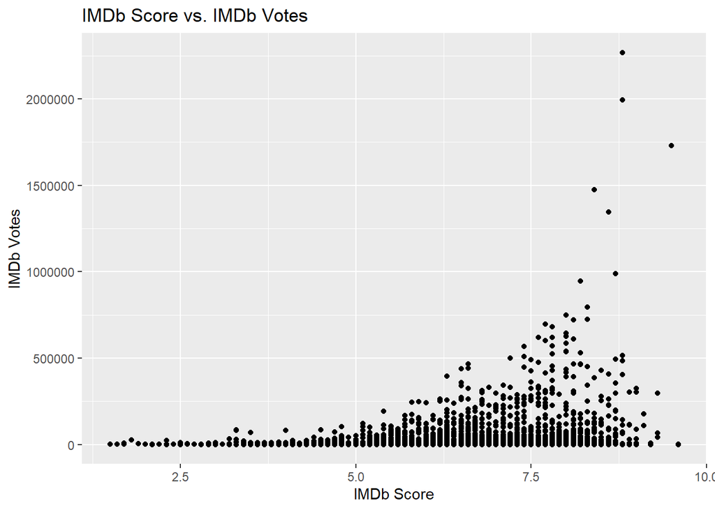

```r
ggplot(netflix_data, aes(x = imdb_score, y = imdb_votes)) +
  geom_point() +
  labs(title = "IMDb Score vs. IMDb Votes",
       x = "IMDb Score", y = "IMDb Votes")
```

```r
#T TEST
t.test(netflix_data$imdb_score ~ netflix_data$release_year < 2010)
```

```
##
##  Welch Two Sample t-test
##
## data:  netflix_data$imdb_score by netflix_data$release_year < 2010
## t = -5.5035, df = 741.11, p-value = 5.133e-08
## alternative hypothesis: true difference in means between group FALSE and group TRUE is not equal to 0
## 95 percent confidence interval:
##  -0.3753723 -0.1779826
## sample estimates:
## mean in group FALSE  mean in group TRUE
##            6.502810            6.779487
```

```r
#ANOVA
aov_result <- aov(netflix_data$imdb_score ~ netflix_data$age_certification)
summary(aov_result)
```

```
##                                  Df Sum Sq Mean Sq F value Pr(>F)
## netflix_data$age_certification   11    705   64.05   52.63 <2e-16 ***
## Residuals                      5271   6414    1.22
## ---
## Signif. codes:  0 '***' 0.001 '**' 0.01 '*' 0.05 '.' 0.1 ' ' 1
```

```r
#Correlation Analysis
correlation <- cor(netflix_data$imdb_score, netflix_data$imdb_votes, use = "complete.obs")
correlation
```

```
## [1] 0.1899542
```

```r
#Chi-Square Test
chisq.test(table(netflix_data$type, netflix_data$age_certification))
```

```
##
##  Pearson's Chi-squared test
##
## data:  table(netflix_data$type, netflix_data$age_certification)
## X-squared = 4464.6, df = 11, p-value < 2.2e-16
```

```r
#Regression Analysis
lm_result <- lm(netflix_data$imdb_score ~ netflix_data$runtime)
summary(lm_result)
```

```
##
## Call:
## lm(formula = netflix_data$imdb_score ~ netflix_data$runtime)
##
## Residuals:
##     Min      1Q  Median      3Q     Max
## -5.1863 -0.6869  0.1034  0.8084  3.2069
##
## Coefficients:
##                        Estimate Std. Error t value Pr(>|t|)
## (Intercept)           6.9098122  0.0357617  193.22   <2e-16 ***
## netflix_data$runtime -0.0047521  0.0004053  -11.73   <2e-16 ***
## ---
## Signif. codes:  0 '***' 0.001 '**' 0.01 '*' 0.05 '.' 0.1 ' ' 1
##
## Residual standard error: 1.146 on 5281 degrees of freedom
## Multiple R-squared:  0.02538,    Adjusted R-squared:  0.02519
## F-statistic: 137.5 on 1 and 5281 DF,  p-value: < 2.2e-16
```